# LatFlow Home Testing Resource Model

Report produced By Cignpost Diagnostics Data Department

Waleed Idrees (Data Scientist) ,Ben Neffendorf (Head of Insight)

2021-11-30

# Introduction to Model

The aim of this model is utilize historical home testing lat flow data and create an efficient resourcing model.

Using Arima forecasting model, forecast is produced which will give us hourly number of tests.

We build our resourcing model based on our hourly forecast and using following assumption:

- Assumptions made in the model are as follows: * Mvine test are 60% of total home tests Webform based tests are 40% of total home tests
- for mvine tests 1 tests takes approximately 2 mins to complete
- for webform tests 1 tests takes 10 mins to complete
- shifts are on 4 hour basis i.e 8-12, 12-16, 16-20, 20-24.

[output not shown]

# Historical Trend analysis

In order to create a good model we need to look at historical data to understand the hourly and per 4 hour trends. graph below shows that 8-12 and 16-20 shifts are the busiest periods of the day.

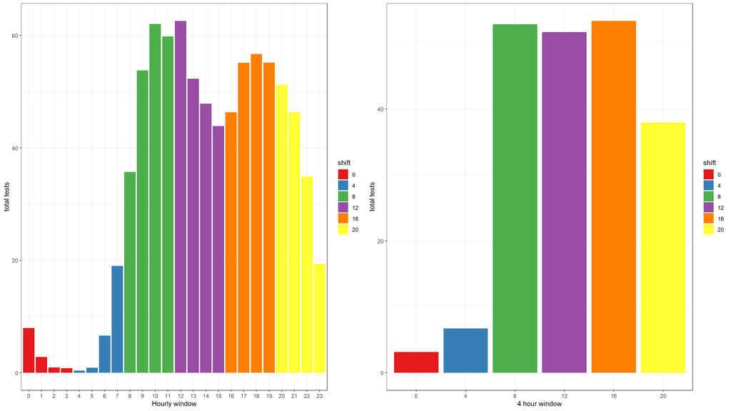

graph below shows hourly trend comparison between weekdays and weekends. blue line shows weekend tests and red line shows weekdays trend. Higher number of tests are booked over the weekend from 8am to 12pm.

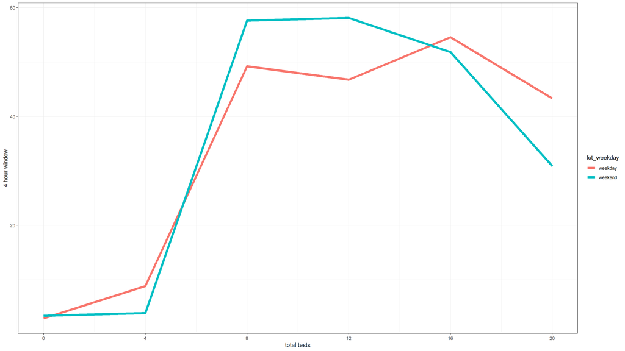

Table below shows a sample of training data

| Date | total_tests | Year | Month | Day | Weekday_names | week_no | Months_no |
| --- | --- | --- | --- | --- | --- | --- | --- |
| 2021-11-16 00:00:00 | 16 | 2021 | 11 | 16 | Tuesday | 46 | 11 |
| 2021-11-15 23:00:00 | 14 | 2021 | 11 | 15 | Monday | 46 | 11 |
| 2021-11-15 22:00:00 | 36 | 2021 | 11 | 15 | Monday | 46 | 11 |
| 2021-11-15 21:00:00 | 45 | 2021 | 11 | 15 | Monday | 46 | 11 |
| 2021-11-15 20:00:00 | 63 | 2021 | 11 | 15 | Monday | 46 | 11 |
| 2021-11-15 19:00:00 | 82 | 2021 | 11 | 15 | Monday | 46 | 11 |

# Forecasting using Arima Model

Using Arima forecasting model, forecast is produced which will give us hourly number of tests. We need to make sure that our forecasting model is capturing these trends correctly before we can proceed with out model. Blue line in the graph below represents the forecast value and the black line is showing actual number of home tests. Forecasting model is capturing the trends closely.

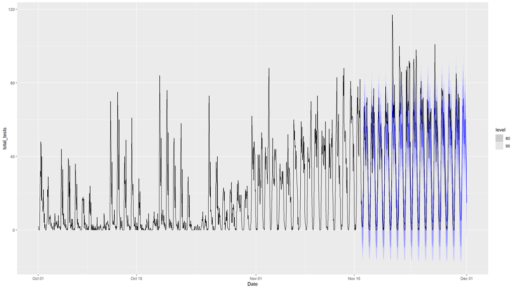

graphs below show a trend comparison between the historical values and foretasted values for home testing.

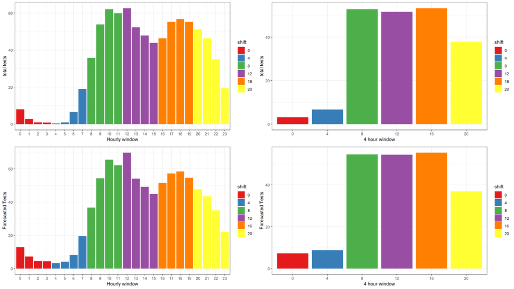

# Resourcing Model

Now we have our forecast. We use two methods to produce final number of workers required per shift:

- Max tests per 4 hour shift
- Avg tests per 4 hour shift

In max tests method we look at max test in any 4 hour shift. One shift is for 4 hours and we cant change the number of workers during a shift. We look at the no of home tests forecaster per hour for a 4 hour a shift and use max test out of 4 hours to work out how many workers are required per shift so they can accommodate busy hour.

For example the the table below we have forecasted tests from 12 untill 4 pm

| Date | forecast | shift | max_test |
| --- | --- | --- | --- |
| 2021-11-16 12:00:00 | 68 | 12 | 68 |
| 2021-11-16 13:00:00 | 52 | 12 | 68 |
| 2021-11-16 14:00:00 | 47 | 12 | 68 |
| 2021-11-16 15:00:00 | 43 | 12 | 68 |

To account for the mvine and web_form tests we divide out forecast into 60/40 proportion for mvine and webform. Calculate number of workers on the basis of average time needed to complete on test. Using these assumptions and forecast we calculate number of workers per shift as shown in the table below. where columns ,max_mvine_prop, max_webform_prop, mvine_time, web_time, workers_mvine_m, workers_webform_m presents proportion of tests, time per test, and worker per shift for mvine and webform respectively.

| Date | forecast | shift | max_test | max_mvine_prop | max_web_prop | mvine_time_pt | web_time_pt | workers_mvine_m | workers_web_m |
| --- | --- | --- | --- | --- | --- | --- | --- | --- | --- |
| 2021-11-16 12:00:00 | 68 | 12 | 68 | 41 | 27 | 2 | 10 | 1 | 5 |
| 2021-11-16 13:00:00 | 52 | 12 | 68 | 41 | 27 | 2 | 10 | 1 | 5 |
| 2021-11-16 14:00:00 | 47 | 12 | 68 | 41 | 27 | 2 | 10 | 1 | 5 |
| 2021-11-16 15:00:00 | 43 | 12 | 68 | 41 | 27 | 2 | 10 | 1 | 5 |

In the average tests method we look at average tests per 4 hour shift. We use average test to work out how many workers are required per shift. For example the the table below shows forecasted test from 12 untill 4 pm shift.

| Date | forecast | shift | avg_test |
| --- | --- | --- | --- |
| 2021-11-16 12:00:00 | 68 | 12 | 53 |
| 2021-11-16 13:00:00 | 52 | 12 | 53 |
| 2021-11-16 14:00:00 | 47 | 12 | 53 |
| 2021-11-16 15:00:00 | 43 | 12 | 53 |

To account for the mvine and web_form tests we divide out forecast into 60/40 proportion for mvine and webform. We calculate number of workers on the basis of average time needed to complete on test.

Using these assumptions and forecast we calculate number of workers per shift as shown in the table below. Where columns ,avg_mvine_prop, avg_webform_prop, mvine_time, webform_time, workers_mvine_a, workers_webform_a presents proportion of tests, time per test, and worker per shift for mvine and webform respectively.

| Date | forecast | shift | avg_test | avg_mvine_prop | avg_web_prop | mvine_time_pt | web_time_pt | workers_mvine_a | workers_web_a |
| --- | --- | --- | --- | --- | --- | --- | --- | --- | --- |
| 2021-11-16 12:00:00 | 68 | 12 | 53 | 32 | 21 | 2 | 10 | 1 | 4 |
| 2021-11-16 13:00:00 | 52 | 12 | 53 | 32 | 21 | 2 | 10 | 1 | 4 |
| 2021-11-16 14:00:00 | 47 | 12 | 53 | 32 | 21 | 2 | 10 | 1 | 4 |
| 2021-11-16 15:00:00 | 43 | 12 | 53 | 32 | 21 | 2 | 10 | 1 | 4 |

# Weighted Average and Max model graphical comparison

Number of workers required with both model is shown with the graph below, with average model showing slightly lower number of workers required per shift.

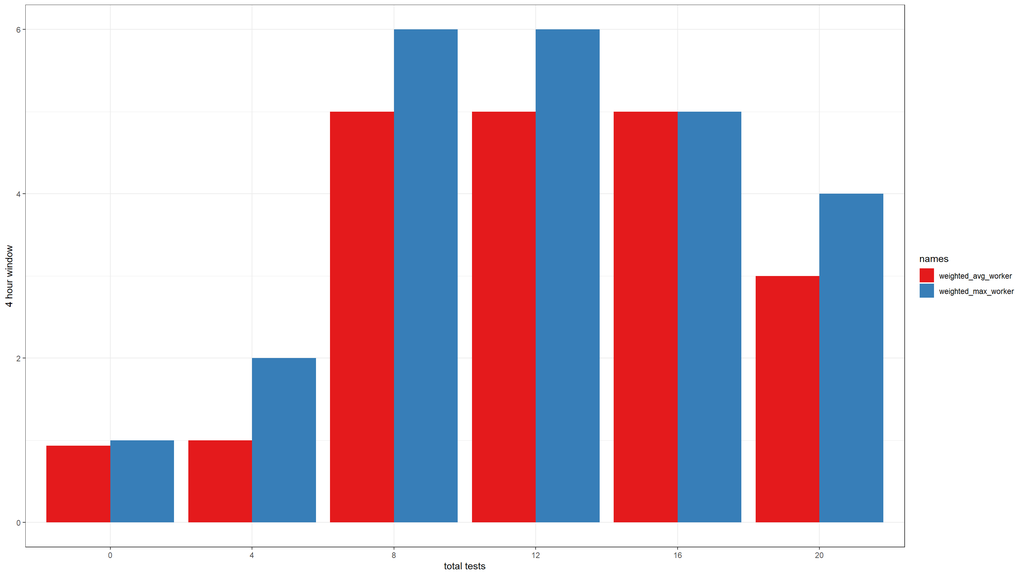